```python
from adsy.display import extended_styles
extended_styles()
```

Toggle Input

# Event Driven Game Theory for Cyber Attack Detection

Justin Grana

Committee members:

Alan Isaac  
Nathan Larson  
David Wolpert  
Josh Neil

## Current Attack Detection

- Signature Based
  - "Keeping up"
- Anomaly Detection
  - False Positives

## Network Example - False Positive

```python
import igraph as ig
G = ig.Graph.Famous('Walther')
x=G.layout()
G.vs['color']='blue'
G.vs[0]['color']='red'
ig.plot(G, layout=x, bbox=(300,300))
```

[figure not shown]

```python
G.vs[18]['color']='red'
ig.plot(G, layout=x, bbox=(300,300))
```

[figure not shown]

```python
G.vs[22]['color']='red'
ig.plot(G, layout=x, bbox=(300,300))
```

[figure not shown]

## Network Example - True Positive

```python
G.vs['color']='blue'
G.vs[12]['color']='red'
G.vs[11]['color']='red'
G.vs[10]['color']='red'
ig.plot(G, layout=x, bbox=(300,300))
```

[figure not shown]

## Elevator Pitch

"To derive a boundedly rational strategy of a cyber criminal using a novel game theoretic framework and exploit that knowledge to develop an attack detector that is superior to the current state of the art."

## "To derive a boundedly rational strategy of a cyber criminal..."

- Attacker vs. Defender
- Game Theory
- Why boundedly?

*Question 1: Given a network parameterization, what is the optimal attacker strategy"*

## "...using a novel game theoretic framework..."

- Traditional Game Theory
  - Extensive Form
  - Differential
  - Continuous Time Stochastic Games

*Question 2: How well and to what extent does the novel framework escape the issues associated with previous approaches*

## "... and exploit that knowledge to develop an attack detector superior to the current state of the art."

*Question 3: How can information of attacker behavior be exploited to improve attack detection*

## Likelihood vs. Likelihood Ratio - A Simple Example

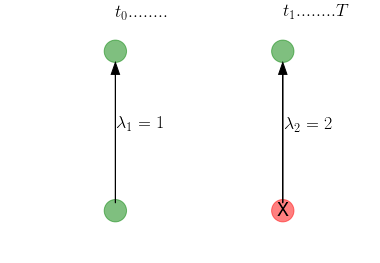

```python
from matplotlib import pyplot as plt
from matplotlib import rc
rc('text', usetex=True)
%matplotlib inline
fig, ax = plt.subplots()
ax.scatter([0,0], [0,1], s=[500, 500], color=['green']*2, alpha =.5)
#ax.axis('off')
ax.arrow(0,.05, 0,.88,  color='black', length_includes_head=True, width=.00005, head_width=.05)
ax.text(.005,.5, "$\lambda_1=1$", fontsize=18)


ax.scatter([1,1], [0,1], s=[500, 500], color=['red', 'green'], alpha =.5)
ax.axis('off')
ax.arrow(1,.05, 0,.88,  color='black', length_includes_head=True, width=.00005, head_width=.05)
ax.text(1.005,.5, "$\lambda_2=2$", fontsize=18)
ax.set_xlim(-.5, 1.5)
ax.text(0, 1.2, '$t_0........$', fontsize=18)
ax.text(1, 1.2, '$t_1........T$', fontsize=18)
ax.text(1,0, 'X', fontsize=18, ha='center', va='center')
print
```

- Given a time interval $[0,T]$ and data $D$ that contains message times...
  - Simple Likelihood Detector $=P(D| \lambda_1) = \frac{(\lambda _1T)^ke^{-\lambda_1 T}}{k!}$
  - Likelihood Ratio Detector (Denominator) - $P=(D| \lambda_1, \lambda_2, t_1) = \frac{(\lambda_1 t_1)^{k_{t_1}}e^{-\lambda_1 T}}{k_{t_1}!} \times \frac{(\lambda_2 (T-t_1))^{k_{T}}e^{-\lambda_2 (T-t_1)}}{k_{T}!}$
  - **But in the real world, the infection times are unknown**
  - Denominator = $\int_0^Tdt_1\frac{(\lambda_1 t_1)^{k_{t_1}}e^{-\lambda_1 T}}{k_{t_1}!} \times \frac{(\lambda_2 (T-t_1))^{k_{T}}e^{-\lambda_2 (T-t_1)}}{k_{T}!}\times \lambda_m e^{-\lambda_mt_1} = P(D|\lambda_1, \lambda_2)$

## ROC Analysis

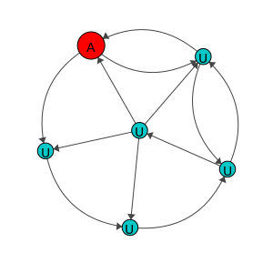

```python
from IPython.display import Image
Image('g1.png')
```

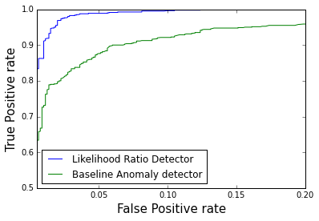

```python
Image('roc1.png')
```

## Model Misspecification

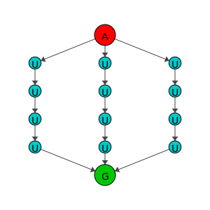

```python
Image('misspecifnet.png')
```

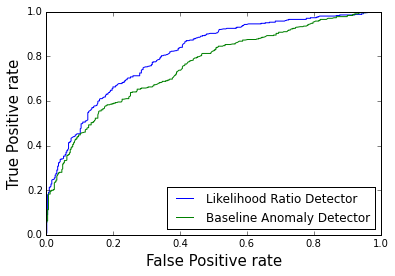

```python
Image('rocmis1-1.png')
```

So, How can information of attacker behavior be exploited to improve attack detection?

## Stochastic Finite Transducer Nets and Event Driven Game Theory

### SFT-Nets

- Directed (generally not acyclic) Graph
- Nodes
  - Internal States
- Messages
- Events
  - Change of state or sending of a message
  - Spontaneous or Stimulated
- Rates
  - Rate at which an event happens
- Event Distribution
  - Given an event happens, determines *which* event happens.

With an SFT-Net specified (with the event rates Poisson), it is possible to specify a **generator** matrix that governs the state of the system.

## Brief aside ...

Recall that in the discrete time representation, the system evolves according to a probability transition matrix given by:

$\mathbf{A} = \begin{bmatrix} a_{1,1} &\ldots &a_{1,n} \\ \vdots & \ddots & \vdots \\ a_{n,1} & \ldots & a_{n,n}\\ \end{bmatrix}$

The continuous time analog is called a \textbf{generator} or transition rate matrix given by

$\mathbf{Q} = \begin{bmatrix} -\sum_{i\neq 1}^n \lambda_{1,i} &\ldots &\lambda_{1,n} \\ \vdots & -\sum_{i\neq 2}^n \lambda_{2,i}& \vdots \\ \lambda_{n,1} & \ldots & -\sum_{i\neq 3}^n \lambda_{2,i} \\ \end{bmatrix}$

The generator completely governs the evolution of the system:

$P(X(t) = x | X(0)) = [e^{t\mathbf{Q}}]_{X(0)}$

## SFT-Net for a cyber scenario

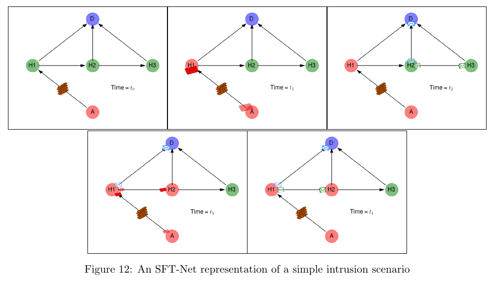

```python
Image('sftex1.png')
```

### Game Theory?

- SFTs have elements controlled by humans as to maximize an expected utility.

### Outline of Initial Optimization Experiments

- SFTs are either a hosts, an attacker or a defender.
- The defender uses a simple likelihood detector and it is fixed.
- The attacker receives a reward upon infecting some hosts.
- The rate at which he "get's the opportunity" to send a message is pre-set.
- When he get's the opportunity to send a message, he **decides** to send a message along an edge or to do nothing at all.
- The strategies are computed using Monte Carlo Tree Search (MCTS)

## Preliminary Results 1

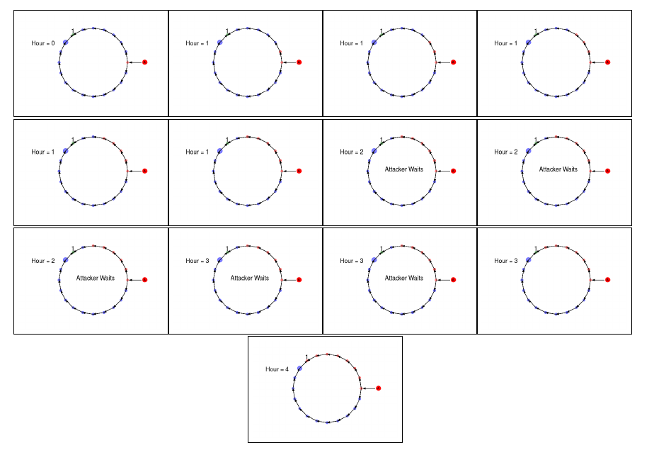

```python
Image('sftres1.png')
```

## Preliminary Results 2

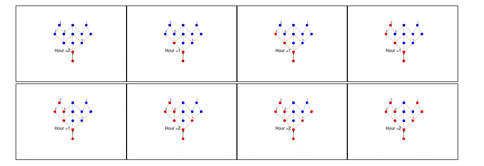

```python
Image('sftres2.png')
```

## Preliminary Results 3

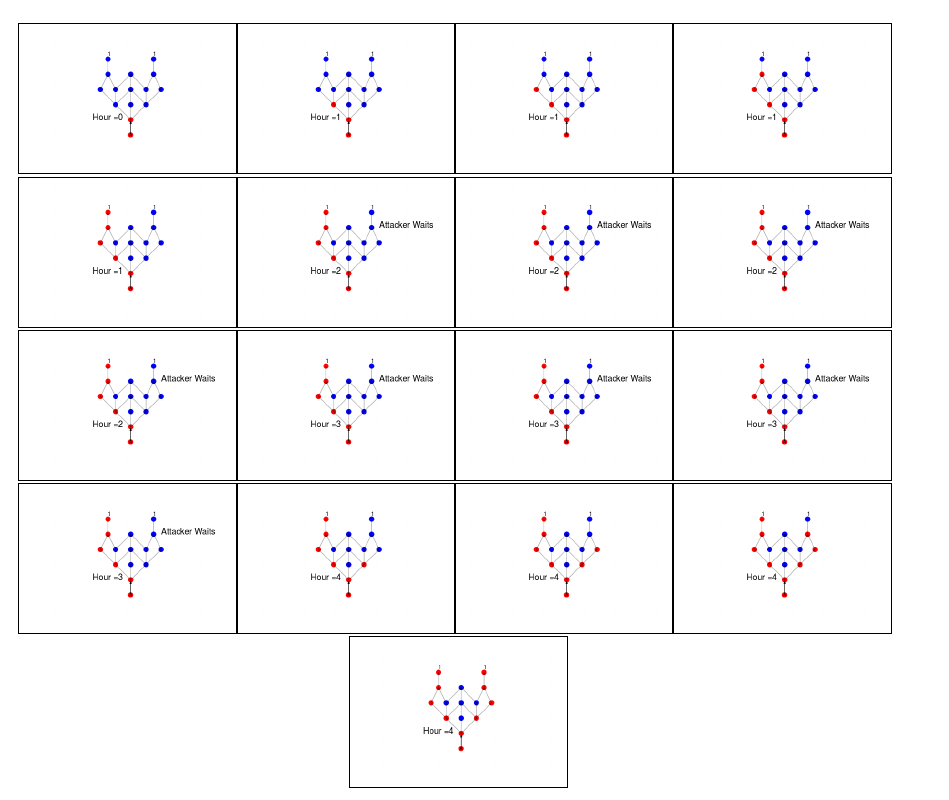

```python
Image('sftres3.png')
```

## How well and to what extent does the novel framework escape the issues associated with previous approaches?

- Pretty good (ish)

## Future

- Immediate
  - Extend the small scenarios to a level-k game.
  - Compare solutions from the level-k game with real attacker behavior
  - Incorporate attacker's behavior into ROC analysis
- Long Term
  - Scale results from small networks to large (real world networks)